# Metatranscriptomics descriptive analysis

Julien Tap

```r
library(ggplot2)
library(scales)
library(ade4)
library(reshape2)
library(grid)
library(knitr)
data(metatrans_alimintest)
```

## Introduction

Four subjects were subjected to 10g of fiber diet per day first then 40g fiber per diet after a washout period of 15 days. In addition to 16S rRNA gene sequencing, metatranscriptomics was also done from stool samples. Here we aimed to compare gut microbiota composition, taxonomic and functional activies.

## Results

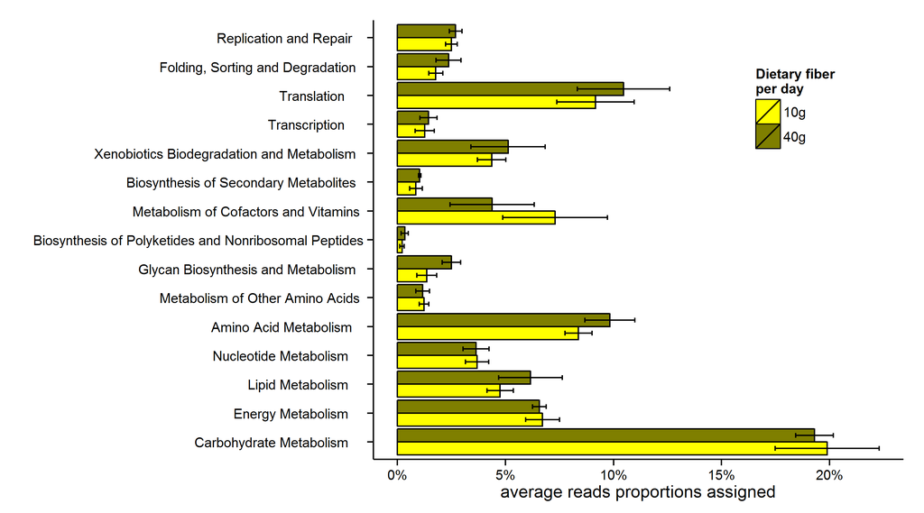

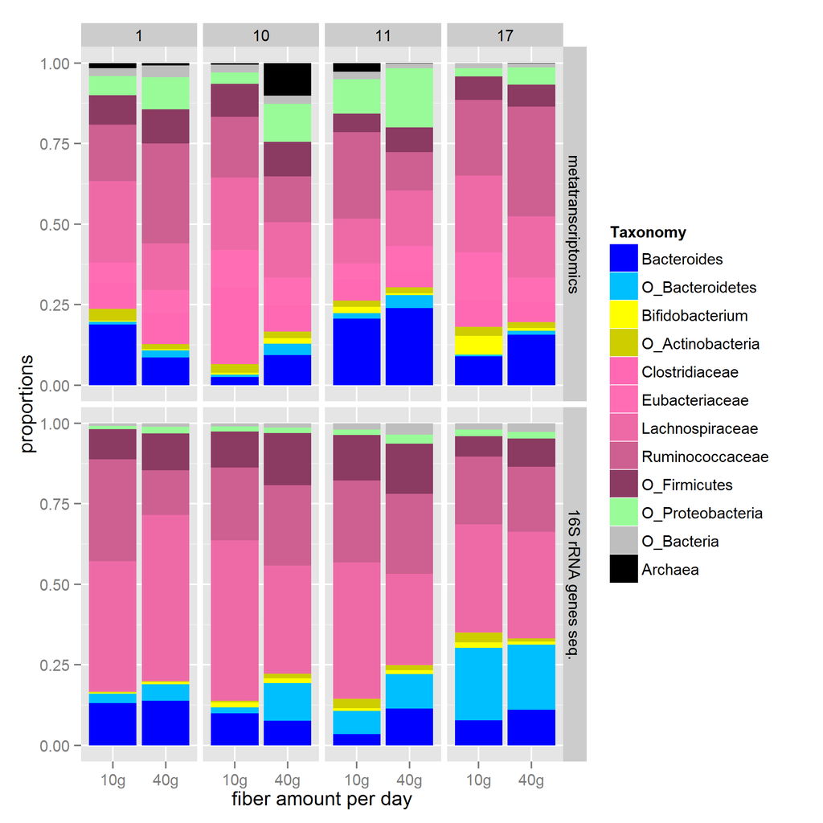

Taxonomic comparison between 16S and metatranscriptomics dataset

**Fig. S6 (a): Taxonomic comparison between 16S and metatranscriptomics dataset.**

A partial triadic analysis (between 10g vs 40g of fiber) combined with a co-inertia analysis (KEGG metatranscriptomics data vs taxonomic metatranscriptomics) is done. The aime of this analysis is to test the co-structure between taxonomic and functional activities and explore this under different conditions of fiber amount.

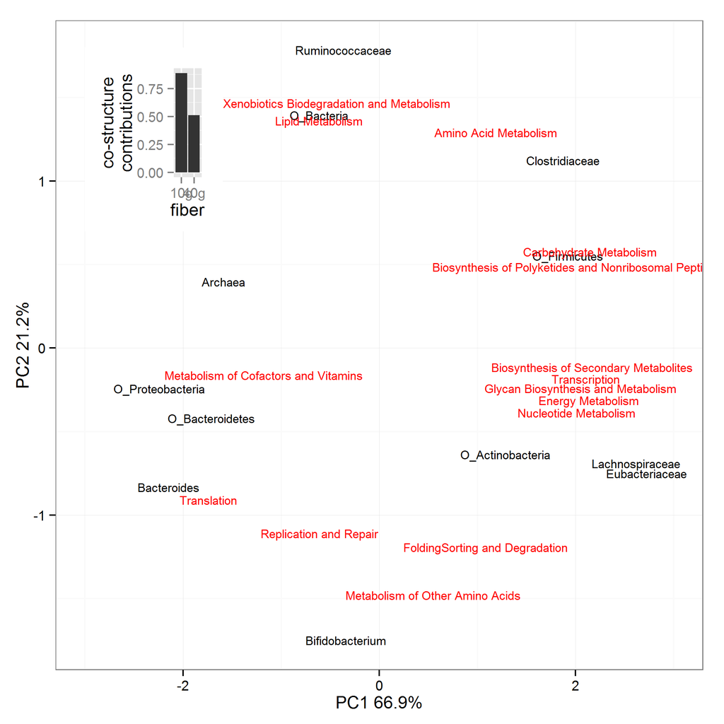

**Fig. S6 (b): Co-inertia compromise between taxonomic and functional activities in the gut microbiota with 10g or 40 fiber diet**. Combined with a partial triadic analysis, the contribution of different fiber amount to the link between taxonomic and function is measured (inset graphic). after 10g of fiber, the link between taxonomic and functional activities is higher than 40g of fiber. ________________________________________

## Conclusion

- Microbial composition and activities are linked. Main difference might be due to the metatranscriptomics reads annotation biaised by reference database.
- A coinertia analysis combined with a partial tridiac analysis allowed us to decipher the link between taxonomic and functional activities across diet change. Lachnospiraceae, Eubacteriaceae and other Firmicutes were linked to glycan metabolism and energy metabolism. Bacteroides and Proteobacteria were linked translation and metabolism of cofactors and vitamins. This link is stronger after 10g of fiber compared to 40g.